# Analysis of U.S. Storm Event Data and it’s Impact on Public Health and the Economy

Gaurab Kundu

2022-10-19

# Synopsis

In this project, we analyze the storm database taken from the U.S. National Oceanic and Atmospheric Administration (NOAA). We estimate the fatalities, injuries, property damage, and crop damage for each type of event (e.g., Flood, Typhoon, Tornado, Hail, Hurricane, etc.). Our goal is to determine which event is most harmful to US population (health) and which event has the largest economic consequences. Our analysis on Fatalities and Injuries conclude that Tornado is the most harmful event in respect to the US health (population). On the other hand, based on the Property and Cost damage, we conclude that Flood has the greatest economic consequences to the US.

# Introduction

Storms and other severe weather events can cause both public health and economic problems for communities and municipalities. Many severe events can result in fatalities, injuries, and property damage, and preventing such outcomes to the extent possible is a key concern.

This project involves exploring the U.S. National Oceanic and Atmospheric Administration’s (NOAA) storm database. This database tracks characteristics of major storms and weather events in the United States, including when and where they occur, as well as estimates of any fatalities, injuries, and property damage.

# Data

The data for this assignment come in the form of a comma-separated-value file compressed via the bzip2 algorithm to reduce its size. You can download the file from the following link:

Storm Data [47Mb] There is also some documentation of the database available. Here you will find how some of the variables are constructed/defined.

National Weather Service Storm Data Documentation National Climatic Data Center Storm Events FAQ The events in the database start in the year 1950 and end in November 2011. In the earlier years of the database there are generally fewer events recorded, most likely due to a lack of good records. More recent years should be considered more complete.

# Questions

## The data analysis address the following questions:

1. Across the United States, which types of events are most harmful with respect to population health?
2. Across the United States, which types of events have the greatest economic consequences?

# Data Processing

## Loading required libraries

```r
library(data.table)
library(ggplot2)
```

## Loading the Data into R

```r
data <- read.csv("repdata_data_StormData.csv.bz2", header = TRUE, sep=",")
```

## Inspecting the Data

```r
colnames(data) #checking column names
```

```
##  [1] "STATE__"    "BGN_DATE"   "BGN_TIME"   "TIME_ZONE"  "COUNTY"
##  [6] "COUNTYNAME" "STATE"      "EVTYPE"     "BGN_RANGE"  "BGN_AZI"
## [11] "BGN_LOCATI" "END_DATE"   "END_TIME"   "COUNTY_END" "COUNTYENDN"
## [16] "END_RANGE"  "END_AZI"    "END_LOCATI" "LENGTH"     "WIDTH"
## [21] "F"          "MAG"        "FATALITIES" "INJURIES"   "PROPDMG"
## [26] "PROPDMGEXP" "CROPDMG"    "CROPDMGEXP" "WFO"        "STATEOFFIC"
## [31] "ZONENAMES"  "LATITUDE"   "LONGITUDE"  "LATITUDE_E" "LONGITUDE_"
## [36] "REMARKS"    "REFNUM"
```

## Subsetting the Data

We are only interested in the column related to health and economic impacts. Therefore, only the following columns are needed and we can remove the rest.

### EVTYPE

### FATALITIES

### INJURIES

### PROPDMG

### PROPDMGEXP

### CROPDMG

### CROPDMGEXP

```r
selection <- c('EVTYPE', 'FATALITIES', 'INJURIES', 'PROPDMG', 'PROPDMGEXP', 'CROPDMG', 'CROPDMGEXP')
data <- data[, selection]
summary(data)
```

```
##     EVTYPE            FATALITIES          INJURIES            PROPDMG
##  Length:902297      Min.   :  0.0000   Min.   :   0.0000   Min.   :   0.00
##  Class :character   1st Qu.:  0.0000   1st Qu.:   0.0000   1st Qu.:   0.00
##  Mode  :character   Median :  0.0000   Median :   0.0000   Median :   0.00
##                     Mean   :  0.0168   Mean   :   0.1557   Mean   :  12.06
##                     3rd Qu.:  0.0000   3rd Qu.:   0.0000   3rd Qu.:   0.50
##                     Max.   :583.0000   Max.   :1700.0000   Max.   :5000.00
##   PROPDMGEXP           CROPDMG         CROPDMGEXP
##  Length:902297      Min.   :  0.000   Length:902297
##  Class :character   1st Qu.:  0.000   Class :character
##  Mode  :character   Median :  0.000   Mode  :character
##                     Mean   :  1.527
##                     3rd Qu.:  0.000
##                     Max.   :990.000
```

We also only need to use the data where fatalities, injuries, or damages occured.

```r
data <- as.data.table(data)
data <- data[(EVTYPE != "?" & (INJURIES > 0 | FATALITIES > 0 | PROPDMG > 0 | CROPDMG > 0)),
             c("EVTYPE", "FATALITIES", "INJURIES", "PROPDMG", "PROPDMGEXP", "CROPDMG", "CROPDMGEXP")]
```

## Converting the exponent columns (PROPDMGEXP and CROPDMGEXP)

We need to convert the exponent values from K, M, B to 1000, 1000000, and 1000000000.

```r
cols <- c("PROPDMGEXP", "CROPDMGEXP")
data[,  (cols) := c(lapply(.SD, toupper)), .SDcols = cols]

PROPDMGKey <-  c("\"\"" = 10^0,
                 "-" = 10^0, "+" = 10^0, "0" = 10^0, "1" = 10^1, "2" = 10^2, "3" = 10^3,
                 "4" = 10^4, "5" = 10^5, "6" = 10^6, "7" = 10^7, "8" = 10^8, "9" = 10^9,
                 "H" = 10^2, "K" = 10^3, "M" = 10^6, "B" = 10^9)
CROPDMGKey <-  c("\"\"" = 10^0, "?" = 10^0, "0" = 10^0, "K" = 10^3, "M" = 10^6, "B" = 10^9)

data[, PROPDMGEXP := PROPDMGKey[as.character(data[,PROPDMGEXP])]]
data[is.na(PROPDMGEXP), PROPDMGEXP := 10^0 ]

data[, CROPDMGEXP := CROPDMGKey[as.character(data[,CROPDMGEXP])] ]
data[is.na(CROPDMGEXP), CROPDMGEXP := 10^0 ]
```

## Creating two new columns of Property Cost and Crop Cost

Combining the coefficient (mantissa) and exponent part of Property and Crop Damage.

```r
data <- data[, .(EVTYPE, FATALITIES, INJURIES, PROPDMG, PROPDMGEXP, PROPCOST = PROPDMG * PROPDMGEXP, CROPDMG, CROPDMGEXP, CROPCOST = CROPDMG * CROPDMGEXP)]
```

# Analysis

## Estimating the total of Fatalities and Injuries (Health Impacts)

In order to know the health impact, we estimate the total of Fatalities and Injuries for each event.

```r
Health_Impact <- data[, .(FATALITIES = sum(FATALITIES), INJURIES = sum(INJURIES), TOTAL_HEALTH_IMPACTS = sum(FATALITIES) + sum(INJURIES)), by = .(EVTYPE)]

Health_Impact <- Health_Impact[order(-TOTAL_HEALTH_IMPACTS), ]

Health_Impact <- Health_Impact[1:10, ]

head(Health_Impact, 10)
```

```
##                EVTYPE FATALITIES INJURIES TOTAL_HEALTH_IMPACTS
##  1:           TORNADO       5633    91346                96979
##  2:    EXCESSIVE HEAT       1903     6525                 8428
##  3:         TSTM WIND        504     6957                 7461
##  4:             FLOOD        470     6789                 7259
##  5:         LIGHTNING        816     5230                 6046
##  6:              HEAT        937     2100                 3037
##  7:       FLASH FLOOD        978     1777                 2755
##  8:         ICE STORM         89     1975                 2064
##  9: THUNDERSTORM WIND        133     1488                 1621
## 10:      WINTER STORM        206     1321                 1527
```

## Estimating the total of Property Cost and Crop Cost (Economic Impacts)

In order to know the economic impact, we estimate the total of Property Cost and Crop Cost for each event.

```r
Eco_Impact <- data[, .(PROPCOST = sum(PROPCOST), CROPCOST = sum(CROPCOST), TOTAL_ECO_IMPACTS = sum(PROPCOST) + sum(CROPCOST)), by = .(EVTYPE)]

Eco_Impact <- Eco_Impact[order(-TOTAL_ECO_IMPACTS), ]

Eco_Impact <- Eco_Impact[1:10, ]

head(Eco_Impact, 10)
```

```
##                EVTYPE     PROPCOST    CROPCOST TOTAL_ECO_IMPACTS
##  1:             FLOOD 144657709807  5661968450      150319678257
##  2: HURRICANE/TYPHOON  69305840000  2607872800       71913712800
##  3:           TORNADO  56947380677   414953270       57362333947
##  4:       STORM SURGE  43323536000        5000       43323541000
##  5:              HAIL  15735267513  3025954473       18761221986
##  6:       FLASH FLOOD  16822673979  1421317100       18243991079
##  7:           DROUGHT   1046106000 13972566000       15018672000
##  8:         HURRICANE  11868319010  2741910000       14610229010
##  9:       RIVER FLOOD   5118945500  5029459000       10148404500
## 10:         ICE STORM   3944927860  5022113500        8967041360
```

# Results

## Question 1: Across the United States, which types of events (as indicated in the EVTYPE variable) are most harmful with respect to population health?

## Answer

We generate histogram to find the top 10 weather events that are most harmful to US population.

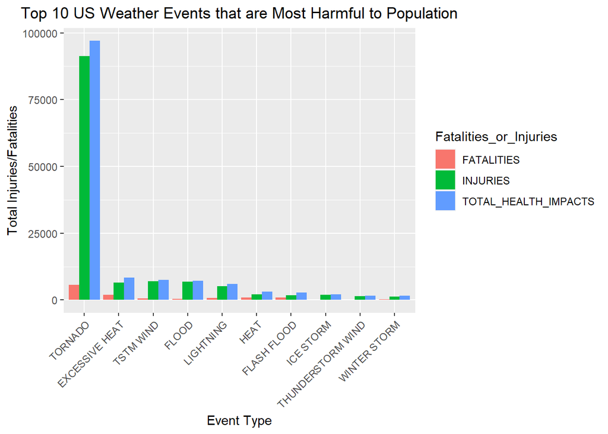

```r
Health_Consequences <- melt(Health_Impact, id.vars = "EVTYPE", variable.name = "Fatalities_or_Injuries")

ggplot(Health_Consequences, aes(x = reorder(EVTYPE, -value), y = value)) +
  geom_bar(stat = "identity", aes(fill = Fatalities_or_Injuries), position = "dodge") +
  ylab("Total Injuries/Fatalities") +
  xlab("Event Type") +
  theme(axis.text.x = element_text(angle=45, hjust=1)) +
  ggtitle("Top 10 US Weather Events that are Most Harmful to Population") +
  theme(plot.title = element_text(hjust = 0.5))
```

## Question 2: Events that have the greatest economic consequences

## Answer

We generate histogram to find the top 10 weather events that have largest cost to US economy.

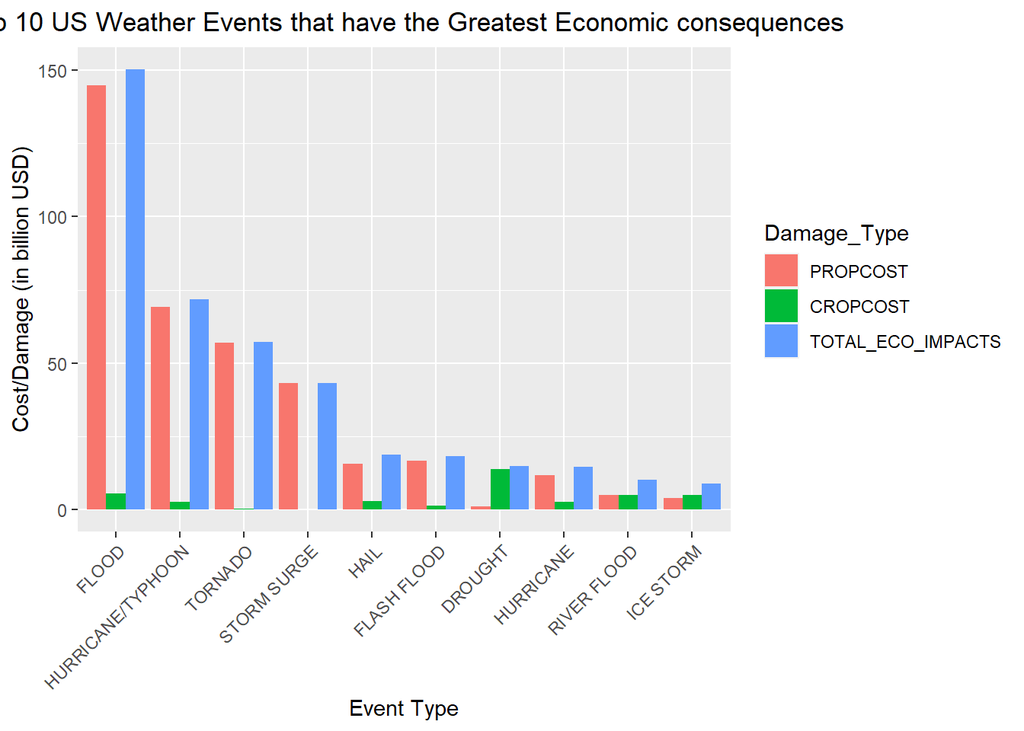

```r
Eco_Consequences <- melt(Eco_Impact, id.vars = "EVTYPE", variable.name = "Damage_Type")

ggplot(Eco_Consequences, aes(x = reorder(EVTYPE, -value), y = value/1e9)) +
  geom_bar(stat = "identity", aes(fill = Damage_Type), position = "dodge") +
  ylab("Cost/Damage (in billion USD)") +
  xlab("Event Type") +
  theme(axis.text.x = element_text(angle=45, hjust=1)) +
  ggtitle("Top 10 US Weather Events that have the Greatest Economic consequences") +
  theme(plot.title = element_text(hjust = 0.5))
```